# Assignment_6

VenkataSaiReddy

2025-04-02

# Question 1: Hierarchical Clustering Using AGNES and DIANA

## Q1-A: Perform Hierarchical Clustering and Plot Dendrograms

```r
library(cluster)
library(e1071)
library(dplyr)
library(tinytex)
library(dbscan)
library(fpc)
```

```r
library(ggplot2)
```

```r
# loading the dataset
wines <- read.csv("C:/R Assignments/Wine-clustering-HC.csv")

# checking the summary of the wines
summary(wines)
```

```
##     Alcohol        Malic_Acid         Ash         Ash_Alcanity
##  Min.   :11.03   Min.   :0.740   Min.   :1.360   Min.   :10.60
##  1st Qu.:12.36   1st Qu.:1.603   1st Qu.:2.210   1st Qu.:17.20
##  Median :13.05   Median :1.865   Median :2.360   Median :19.50
##  Mean   :13.00   Mean   :2.336   Mean   :2.367   Mean   :19.49
##  3rd Qu.:13.68   3rd Qu.:3.083   3rd Qu.:2.558   3rd Qu.:21.50
##  Max.   :14.83   Max.   :5.800   Max.   :3.230   Max.   :30.00
##    Magnesium      Total_Phenols     Flavanoids    Nonflavanoid_Phenols
##  Min.   : 70.00   Min.   :0.980   Min.   :0.340   Min.   :0.1300
##  1st Qu.: 88.00   1st Qu.:1.742   1st Qu.:1.205   1st Qu.:0.2700
##  Median : 98.00   Median :2.355   Median :2.135   Median :0.3400
##  Mean   : 99.74   Mean   :2.295   Mean   :2.029   Mean   :0.3619
##  3rd Qu.:107.00   3rd Qu.:2.800   3rd Qu.:2.875   3rd Qu.:0.4375
##  Max.   :162.00   Max.   :3.880   Max.   :5.080   Max.   :0.6600
##  Proanthocyanins Color_Intensity       Hue             OD280
##  Min.   :0.410   Min.   : 1.280   Min.   :0.4800   Min.   :1.270
##  1st Qu.:1.250   1st Qu.: 3.220   1st Qu.:0.7825   1st Qu.:1.938
##  Median :1.555   Median : 4.690   Median :0.9650   Median :2.780
##  Mean   :1.591   Mean   : 5.058   Mean   :0.9574   Mean   :2.612
##  3rd Qu.:1.950   3rd Qu.: 6.200   3rd Qu.:1.1200   3rd Qu.:3.170
##  Max.   :3.580   Max.   :13.000   Max.   :1.7100   Max.   :4.000
##     Proline       Alcohol_Level      Ash_Content        Color_Intensity_Group
##  Min.   : 278.0   Length:178         Length:178         Length:178
##  1st Qu.: 500.5   Class :character   Class :character   Class :character
##  Median : 673.5   Mode  :character   Mode  :character   Mode  :character
##  Mean   : 746.9
##  3rd Qu.: 985.0
##  Max.   :1680.0
```

```r
# Extract only the numeric columns from the wines
numeric_wines <- wines[, sapply(wines, is.numeric)]

# Display summary statistics of numeric columns
summary(numeric_wines)
```

```
##     Alcohol        Malic_Acid         Ash         Ash_Alcanity
##  Min.   :11.03   Min.   :0.740   Min.   :1.360   Min.   :10.60
##  1st Qu.:12.36   1st Qu.:1.603   1st Qu.:2.210   1st Qu.:17.20
##  Median :13.05   Median :1.865   Median :2.360   Median :19.50
##  Mean   :13.00   Mean   :2.336   Mean   :2.367   Mean   :19.49
##  3rd Qu.:13.68   3rd Qu.:3.083   3rd Qu.:2.558   3rd Qu.:21.50
##  Max.   :14.83   Max.   :5.800   Max.   :3.230   Max.   :30.00
##    Magnesium      Total_Phenols     Flavanoids    Nonflavanoid_Phenols
##  Min.   : 70.00   Min.   :0.980   Min.   :0.340   Min.   :0.1300
##  1st Qu.: 88.00   1st Qu.:1.742   1st Qu.:1.205   1st Qu.:0.2700
##  Median : 98.00   Median :2.355   Median :2.135   Median :0.3400
##  Mean   : 99.74   Mean   :2.295   Mean   :2.029   Mean   :0.3619
##  3rd Qu.:107.00   3rd Qu.:2.800   3rd Qu.:2.875   3rd Qu.:0.4375
##  Max.   :162.00   Max.   :3.880   Max.   :5.080   Max.   :0.6600
##  Proanthocyanins Color_Intensity       Hue             OD280
##  Min.   :0.410   Min.   : 1.280   Min.   :0.4800   Min.   :1.270
##  1st Qu.:1.250   1st Qu.: 3.220   1st Qu.:0.7825   1st Qu.:1.938
##  Median :1.555   Median : 4.690   Median :0.9650   Median :2.780
##  Mean   :1.591   Mean   : 5.058   Mean   :0.9574   Mean   :2.612
##  3rd Qu.:1.950   3rd Qu.: 6.200   3rd Qu.:1.1200   3rd Qu.:3.170
##  Max.   :3.580   Max.   :13.000   Max.   :1.7100   Max.   :4.000
##     Proline
##  Min.   : 278.0
##  1st Qu.: 500.5
##  Median : 673.5
##  Mean   : 746.9
##  3rd Qu.: 985.0
##  Max.   :1680.0
```

```r
# Normalize the numeric data by centering and scaling (mean = 0, sd = 1)
scaled_wines <- scale(numeric_wines)

# Display summary statistics
summary(scaled_wines)
```

```
##     Alcohol           Malic_Acid           Ash            Ash_Alcanity
##  Min.   :-2.42739   Min.   :-1.4290   Min.   :-3.66881   Min.   :-2.663505
##  1st Qu.:-0.78603   1st Qu.:-0.6569   1st Qu.:-0.57051   1st Qu.:-0.687199
##  Median : 0.06083   Median :-0.4219   Median :-0.02375   Median : 0.001514
##  Mean   : 0.00000   Mean   : 0.0000   Mean   : 0.00000   Mean   : 0.000000
##  3rd Qu.: 0.83378   3rd Qu.: 0.6679   3rd Qu.: 0.69615   3rd Qu.: 0.600395
##  Max.   : 2.25341   Max.   : 3.1004   Max.   : 3.14745   Max.   : 3.145637
##    Magnesium       Total_Phenols        Flavanoids      Nonflavanoid_Phenols
##  Min.   :-2.0824   Min.   :-2.10132   Min.   :-1.6912   Min.   :-1.8630
##  1st Qu.:-0.8221   1st Qu.:-0.88298   1st Qu.:-0.8252   1st Qu.:-0.7381
##  Median :-0.1219   Median : 0.09569   Median : 0.1059   Median :-0.1756
##  Mean   : 0.0000   Mean   : 0.00000   Mean   : 0.0000   Mean   : 0.0000
##  3rd Qu.: 0.5082   3rd Qu.: 0.80672   3rd Qu.: 0.8467   3rd Qu.: 0.6078
##  Max.   : 4.3591   Max.   : 2.53237   Max.   : 3.0542   Max.   : 2.3956
##  Proanthocyanins    Color_Intensity        Hue               OD280
##  Min.   :-2.06321   Min.   :-1.6297   Min.   :-2.08884   Min.   :-1.8897
##  1st Qu.:-0.59560   1st Qu.:-0.7929   1st Qu.:-0.76540   1st Qu.:-0.9496
##  Median :-0.06272   Median :-0.1588   Median : 0.03303   Median : 0.2371
##  Mean   : 0.00000   Mean   : 0.0000   Mean   : 0.00000   Mean   : 0.0000
##  3rd Qu.: 0.62741   3rd Qu.: 0.4926   3rd Qu.: 0.71116   3rd Qu.: 0.7864
##  Max.   : 3.47527   Max.   : 3.4258   Max.   : 3.29241   Max.   : 1.9554
##     Proline
##  Min.   :-1.4890
##  1st Qu.:-0.7824
##  Median :-0.2331
##  Mean   : 0.0000
##  3rd Qu.: 0.7561
##  Max.   : 2.9631
```

```r
# Open the table to see and visually check the scaled data
View(scaled_wines)
```

### AGNES Clustering and Dendrograms

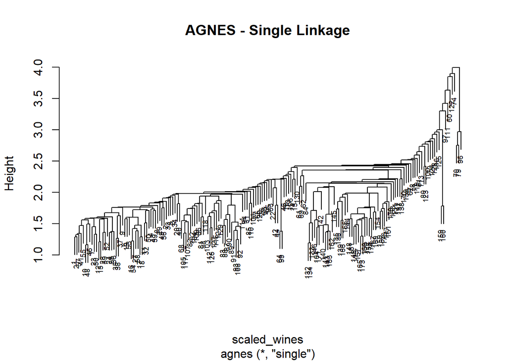

```r
# Perform AGNES using single linkage

agnes_single <- agnes(scaled_wines, method = "single")
pltree(agnes_single, main = "AGNES - Single Linkage", cex = 0.6)
```

## Interpretation

The AGNES dendrogram using single linkage shows how 178 wine samples cluster based on their scaled chemical properties. Most samples merge at a height between 1.0 and 2.0, indicating high similarity. A few clusters, like those containing samples 79, 97, 171, and 174, merge much later around heights of 3.5 to 4.2, showing they are more distinct. The overall chain like shape is typical of single linkage, which forms clusters based on the minimum distance between points, often resulting in less compact groupings.

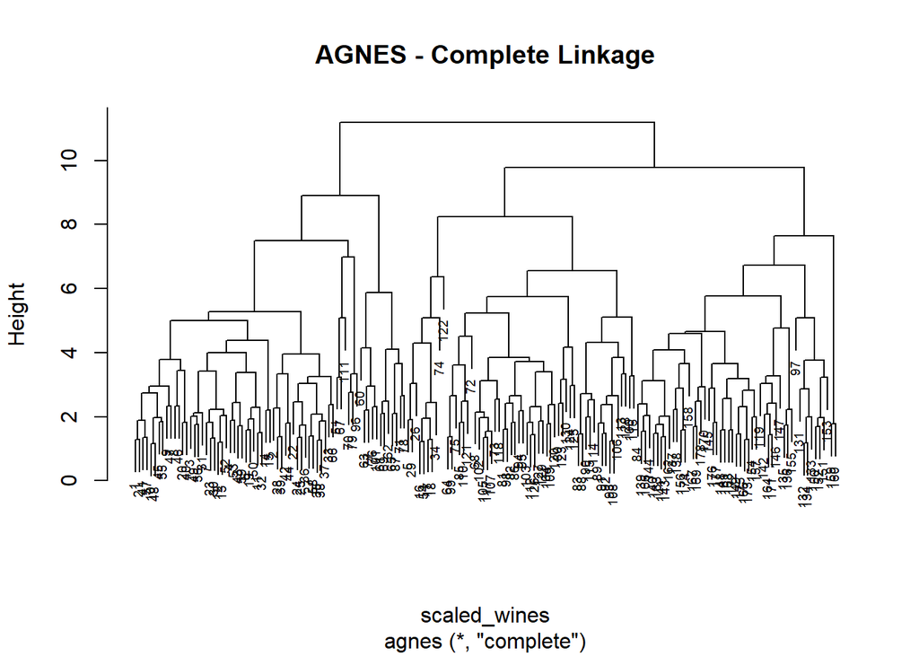

```r
# Perform AGNES using complete linkage
agnes_complete <- agnes(scaled_wines, method = "complete")
pltree(agnes_complete, main = "AGNES - Complete Linkage", cex = 0.6)
```

## Interpretation

AGNES with complete linkage clusters wine samples based on the maximum distance between points, resulting in tighter, more compact clusters.

Most samples merge at lower heights (0 to 4), showing strong similarity in chemical profiles.

Larger clusters form around heights 6 to 10, indicating more distinct groupings.

Samples like 111, 122, and 97 join clusters at higher levels, suggesting they are outliers or less similar.

The dendrogram structure is more balanced and well-separated compared to single linkage, making complete linkage a better choice for distinct clustering.

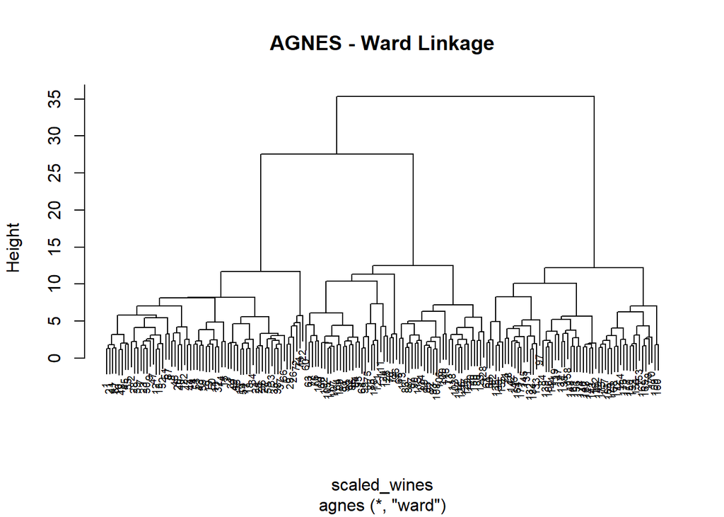

```r
# Perform AGNES using ward linkage
agnes_ward <- agnes(scaled_wines, method = "ward")
pltree(agnes_ward, main = "AGNES - Ward Linkage", cex = 0.6)
```

## Interpretation

Ward linkage minimizes within cluster variance, resulting in compact and well separated clusters. Most wine samples are merged at low heights (0–10), indicating strong similarity. Major clusters only combine at higher levels (25–35), reflecting distinct chemical profiles. The dendrogram structure is balanced and symmetric, suggesting consistent grouping quality. Samples like 97 and 163 join late, indicating they differ more from the rest.

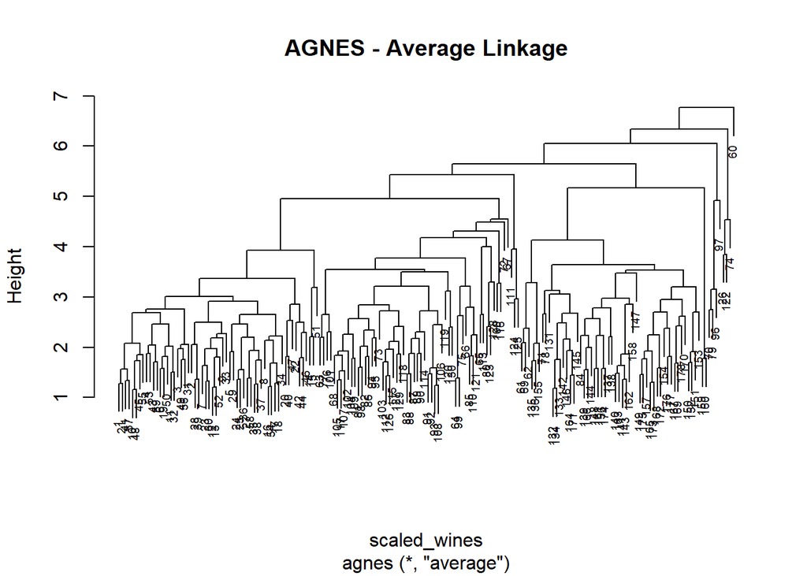

```r
# Perform AGNES using average linkage
agnes_average <- agnes(scaled_wines, method = "average")
pltree(agnes_average, main = "AGNES - Average Linkage", cex = 0.6)
```

## Interpretation

Average linkage clusters samples based on the average distance between all pairs of points in two clusters, striking a balance between single and complete linkage.

Most wine samples merge at heights between 1.0 and 3.5, showing moderate similarity in their chemical composition.

Clusters become more distinct around heights of 5 to 7, especially for samples like 60, 97, and 125, which join later.

The dendrogram shows a moderately balanced structure, suggesting fairly well formed groupings.

This method provides a compromise less chaining than single linkage and less compact than complete or Ward making it suitable for finding moderately separated clusters.

### Overall Interpretation of AGNES Linkage Methods

**Ward linkage** is the best choice, producing compact, balanced, and well-separated clusters by minimizing within cluster variance ideal for identifying distinct wine groups.

**Complete linkage** also performs well, forming tight, distinct clusters with clear separation, though not as statistically optimal as Ward in terms of cluster compactness.

**Average linkage** offers a reasonable compromise, producing moderately compact clusters with a balanced structure less chaining than single, but not as distinct as Ward or complete.

**Single linkage** is the weakest method, creating elongated, chain like clusters due to its reliance on minimum distance leading to poor cluster separation and interpretability.

~~~~~~~~~~~~~~~~~~~~~~~~~~~~~~~~~~~~~~~~~~~~~~~~~~~~~~~~~~~~~~~~~~~~~~~~~~~~~~~~~~~~~~~

### DIANA Clustering and Dendrogram

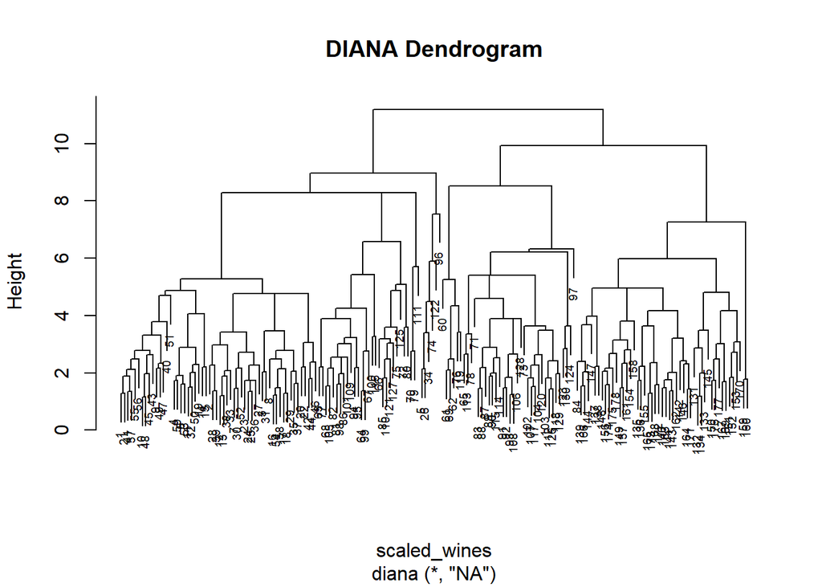

```r
# Perform DIANA (Divisive Analysis)
diana_result <- diana(scaled_wines)
pltree(diana_result, main = "DIANA Dendrogram", cex = 0.6)
```

## Interpretation

DIANA (Divisive Analysis) starts with all data in one large cluster and splits it recursively based on dissimilarity.

In this dendrogram, most wine samples are split into smaller groups at lower heights (0–4), indicating good within cluster similarity.

The most distinct splits occur at higher levels (above 8) samples like 111, 122, and 97 are separated later, showing they differ more from the rest.

The structure is well balanced and hierarchical, reflecting a clear separation of clusters.

DIANA effectively highlights broad differences first, making it suitable for detecting dominant patterns and outliers in the dataset.

## Q1-B: Compare Coefficients

```r
# Compare the clustering quality using coefficients

agnes_ward$ac  # Agglomerative coefficient (AGNES - Ward)
```

```
## [1] 0.9419172
```

```r
diana_result$dc  # Divisive coefficient (DIANA)
```

```
## [1] 0.8000096
```

## Interpretation

The agglomerative coefficient (AC) for AGNES using Ward linkage is 0.942, which is very high and indicates strong, cohesive clustering.

The divisive coefficient (DC) for DIANA is 0.800, which is also good but not as strong as AGNES in this case.

Since Ward’s AC is higher, it suggests that AGNES with Ward linkage forms more reliable and compact clusters than DIANA for this dataset.

# Question 2: Visualize Categorical Variables

## Q2-A: Calculate Median Values by Category

```r
# Calculate and print median alcohol by Alcohol Level

median_alcohol <- wines %>%
  group_by(Alcohol_Level) %>%
  summarise(Median_Alcohol = median(Alcohol, na.rm = TRUE))
print(median_alcohol)
```

```
## # A tibble: 3 × 2
##   Alcohol_Level Median_Alcohol
##   <chr>                  <dbl>
## 1 High                    13.9
## 2 Low                     12.1
## 3 Medium                  13.0
```

### Interpretation of Median Alcohol by Alcohol Level

Higher Median Alcohol Content Is Associated with Higher Alcohol Levels: With the highest median alcohol level (13.86), “High” wines are followed by “Medium” wines (13.05) and “Low” wines (12.08), demonstrating a steady pattern that backs up the Alcohol_Level classification.

Clear Category Separation: The discernible variations in median values among the three levels imply that the division of the wine samples into “Low,” “Medium,” and “High” categories is significant and accurately captures the variations in actual alcohol concentrations.

```r
# Calculate and print median ash by Ash Content
median_ash <- wines %>%
  group_by(Ash_Content) %>%
  summarise(Median_Ash = median(Ash, na.rm = TRUE))
print(median_ash)
```

```
## # A tibble: 3 × 2
##   Ash_Content Median_Ash
##   <chr>            <dbl>
## 1 High              2.70
## 2 Low               2.17
## 3 Moderate          2.4
```

### Interpretation of Median Ash by Ash Content

Median Ash content increases across categories as expected: Wines labeled “Low” have the lowest median Ash (2.170), followed by “Moderate” (2.400), and “High” (2.695), confirming that the Ash_Content classification aligns well with actual ash measurements.

Well-separated groupings: The consistent increase in median values suggests meaningful separation between the three categories, indicating that Ash_Content is a reliable categorical variable for summarizing ash levels in wine samples.

```r
# Calculate and print median color intensity by Color_Intensity_Group
median_color <- wines %>%
  group_by(Color_Intensity_Group) %>%
  summarise(Median_Color = median(Color_Intensity, na.rm = TRUE))
print(median_color)
```

```
## # A tibble: 3 × 2
##   Color_Intensity_Group Median_Color
##   <chr>                        <dbl>
## 1 Dark                          7.65
## 2 Light                         2.9
## 3 Moderate                      5.04
```

### Interpretation of Median Color Intensity by Color_Intensity_Group

The validity of the categorization is confirmed by the expected increase in median color intensity between groups: wines classified as “Light” have the lowest median intensity (2.900), followed by “Moderate” (5.045) and “Dark” wines have the highest (7.650).

Distinct separation between categories: The Color_Intensity_Group categorization effectively captures pertinent variations in wine color intensity, which facilitates visual and sensory characterisation, according to the large deviations in median values.

## Q2-B: Visualize Median Values with Bar Plots

```r
# check the unique values in the Alcohol_Content
unique(median_alcohol$Alcohol_Level)
```

```
## [1] "High"   "Low"    "Medium"
```

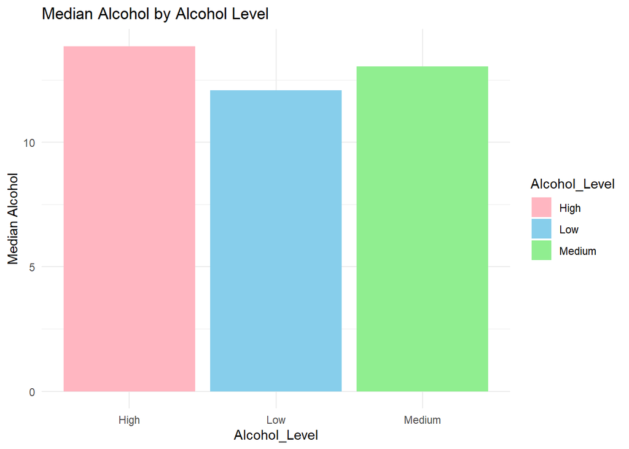

```r
# Bar plot for median alcohol by Alcohol_Level
ggplot(median_alcohol, aes(x = Alcohol_Level, y = Median_Alcohol, fill = Alcohol_Level)) +
  geom_bar(stat = "identity") +
  scale_fill_manual(values = c("Low" = "skyblue", "Medium" = "lightgreen", "High" = "lightpink")) +
  labs(title = "Median Alcohol by Alcohol Level", y = "Median Alcohol") +
  theme_minimal()
```

### Interpretation

As evidenced by the bar plot, wines with a High Alcohol Level contain the most amount of alcohol (in median), moving down to Medium, and ending with “Low”. That is a visual confirmation that the Alcohol_Level grouping mirrors the real alcohol content in the wine samples.

There is a visual differentiation between the height of each groups bar, with the distance most marked between Low 12.08 and High 13.86 showing that we can intuit that this data provides meaningful differences in alcohol levels across the categories.

```r
# check the unique values in the Ash_Content
unique(median_ash$Ash_Content)
```

```
## [1] "High"     "Low"      "Moderate"
```

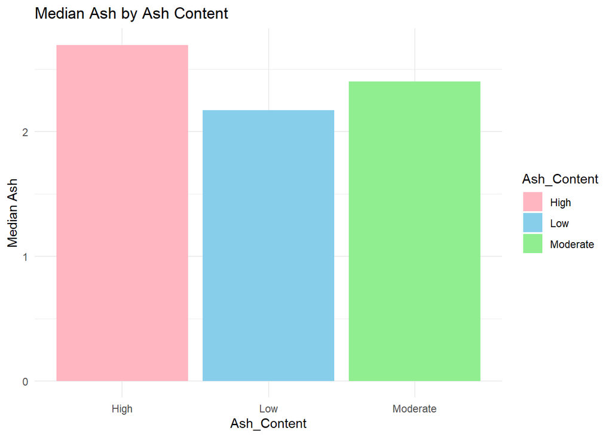

```r
# Bar plot for median ash by Ash_Content

ggplot(median_ash, aes(x = Ash_Content, y = Median_Ash, fill = Ash_Content)) +
  geom_bar(stat = "identity") +
  scale_fill_manual(values = c("Low" = "skyblue", "Moderate" = "lightgreen", "High" = "lightpink")) +
  labs(title = "Median Ash by Ash Content", y = "Median Ash") +
  theme_minimal()
```

### Interpretation

Clearly the median Ash content rises as Ash_Content increases from Low to Moderate to High, with High Ash_Content wines ranked with the highest median Ash (2.70), and Low the lowest (2.17). This validates the Ash_Content categorization.

Since there are, however, marked variations in the heights of the bars, it is quite likely that the grouping into Low, Moderate and High Ash_Content is having the desired effect of discriminating between wine samples in relation to their ash content.

```r
# check the unique values in the color Intensity Group
unique(median_color$Color_Intensity_Group)
```

```
## [1] "Dark"     "Light"    "Moderate"
```

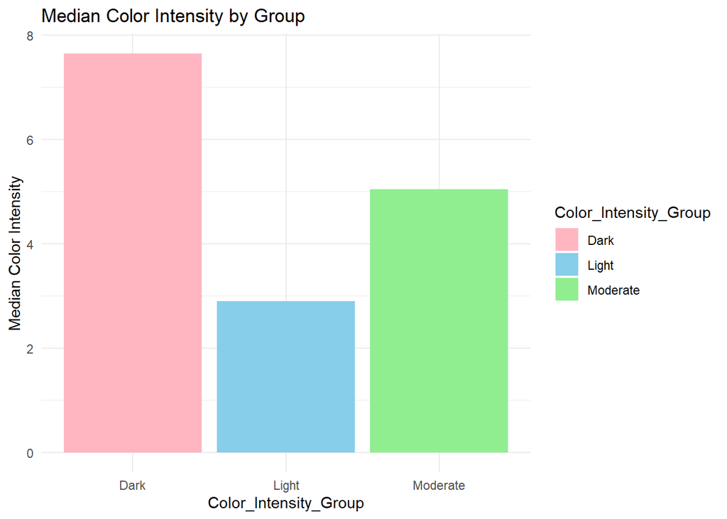

```r
ggplot(median_color, aes(x = Color_Intensity_Group, y = Median_Color, fill = Color_Intensity_Group)) +
geom_bar(stat = "identity") +
  scale_fill_manual(values = c("Dark" = "lightpink", "Moderate" = "lightgreen", "Light" = "skyblue")) +
  labs(title = "Median Color Intensity by Group", y = "Median Color Intensity") +
  theme_minimal()
```

### Interpretation

Logical Data Grouping: The data plotting speaks for itself that, wines in Dark group have the most color intensity - 7.65 median max ~ followed by Moderate group - 5.05 nextand finally the least by Light - 2.90. This shows that the group does relate to actual differences in color intensity between the wines.

Distinctive Visual Separation: The differences in the heights of the bars are clear, showing that the variable Color_Intensity_Group does segregate wines according to their color intensitygroups.

## Q2-C: What do the median values suggest about the distribution of the numeric variables across the different categories? What insights can you derive regarding the characteristics of the wines

Based on the ash content, color intensity, and alcohol level, the groups appear to be significant and appropriately represent variations in the wines’ chemical and visual properties, according to the median values for each category.

Wines classified as “High” actually have higher alcohol content than those in the “Low” or “Medium” classifications, as seen by the median values for alcohol that plainly rise from the “Low” to “High” categories. An analogous pattern may be seen in ash content: wines classified as “High” in ash actually have greater median ash levels, and so forth. One of the similar string trends we can see from color intensity data: “Dark” wines have a significantly greater median color intensity compared to “Light” wines (with “Moderate” wines somewhere in the middle.

These trends suggest that the wines are not randomly distributed among categories. Instead, the classifications reflect real, verifiable differences in the qualities of the wines. A “High Alcohol” or “Dark Color Intensity” wine, say, should pack more oomph than a “Low Alcohol” or “Light Color Intensity” one. This implies that these chemical attributes are correlated and could be used to differentiate or even predict distinguishable wine types and styles.

Overall, median values are a way to see how varied results come when comparing wines, which does give supporting evidence of the importance of categories.

# Q3-A) Comparing AGNES and DIANA: Which Hierarchical Clustering Technique is More Appropriate?

When comparing AGNES and DIANA for the wine dataset, both techniques successfully identified patterns in the data, but AGNES using Ward linkage stands out as the more appropriate method based on the results.

AGNES with Ward linkage produced highly compact, well separated clusters, with a strong agglomerative coefficient of 0.942, which indicates excellent internal cohesion within clusters. The dendrogram revealed a balanced structure, suggesting that wines with similar chemical properties are grouped tightly and distinctly. The method also allowed clear visualization of the clusters and outliers, which is ideal for interpretation and presentation.

In contrast, DIANA, while still effective, showed a slightly lower divisive coefficient of 0.800. This suggests that its cluster separation, while still good, is not as tight or consistent as AGNES. DIANA’s dendrogram was helpful in identifying major distinctions early in the process, which is useful for spotting dominant patterns or broad divisions in the data, but it lacked the refined separation AGNES offered in finer cluster details.

Key insights observed from the AGNES clusters (especially Ward):

Samples like 97 and 163 consistently appeared as outliers, reinforcing their distinct chemical profiles.

Most wine samples clustered smoothly at lower heights, especially with Ward, indicating overall strong similarity across many of the wines.

The groupings appear to align with categorical variables like Alcohol_Level, Ash_Content, and Color_Intensity_Group, showing that chemical measurements meaningfully correspond to wine classifications.

**Conclusion:** Between the two, AGNES with Ward linkage is the more appropriate choice for analyzing the wine dataset due to its stronger cluster cohesion, clearer separation, and better overall structure.

# Q3-B) Would K-Means or DBSCAN Be More Suitable?

Even though AGNES (Ward) performs admirably on this dataset, it’s crucial to think about whether a non-hierarchical approach like K-Means or DBSCAN would be more appropriate.

**K-Means:** When the number of clusters is known or can be accurately calculated, K-Means is frequently successful. Given the continuous numeric variables in the wine dataset, K-Means is probably going to do well. Since the data is already standardized, it makes the assumption that the cluster forms are spherical, which meets the assumptions quite nicely.

The problem with K-Means, though, is figuring out how many clusters to use beforehand, which isn’t always easy. Additionally, K-Means is susceptible to outliers, which may bias cluster centers because we have observed outliers like sample 97 to occur across approaches.

**DBSCAN:**

In contrast, DBSCAN is quite good at identifying noise and clusters of any shape. It works especially well when there are outliers in the data, which we are aware of in this case. However, DBSCAN’s performance can be highly dependent on parameter adjustment, particularly eps and minPts, and it may have trouble with high-dimensional data (the wine dataset contains 13+ features). Additionally, it does not ensure that the same number of clusters will be created as other approaches, which might occasionally result in less interpretable findings in structured datasets like this one.

**Final Thoughts:**

If rapid clustering with distinct cluster counts is the aim, K-Means would be a good substitute, particularly after figuring out the ideal number of clusters using the elbow technique or silhouette scores.

DBSCAN might not be the greatest option for this specific dataset with its organized chemical profiles, but it would be superior for identifying outliers or less compact clusters.

**Conclusion:** The capacity of AGNES with Ward linkage to generate interpretable, cohesive, and well-separated clusters that correspond with known wine qualities makes it the most appropriate method overall for this research, even though K-Means is a solid complimentary technique, particularly with the standardized data.